# Part II - Loan Data Exploration

## by Eniola Ogunmona

## Investigation Overview

In this investigation, I am interested in the factors that affect a loan’s outcome status. The main focus was on the original amount of the loan, borrower rate, monthly loan payment, range of income and credit grade

## Dataset Overview

The data set contains 113,937 loans with 81 variables on each loan, including loan amount, interest rate, current loan status, borrower income.

## Distribution of Loan Status

Most of the loans are currently running and completed. We have a few loans that are charged off, defaulted, past due, cancelled or final payment been made.

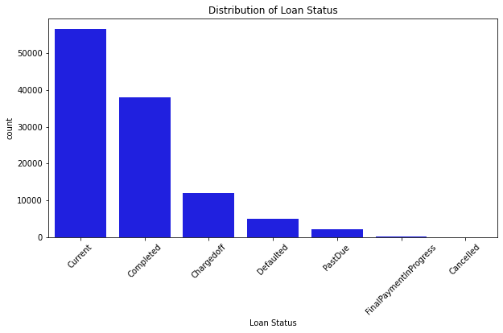

## Distribution of Loan Original Amount

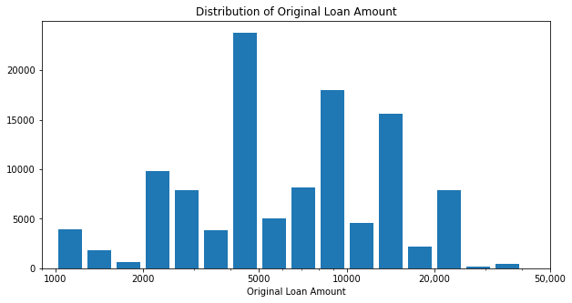

## Distribution of Borrower Rate

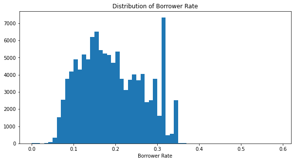

## Borrower rate vs. Loan Original Amount

There is a negative relationship between loan original amount and borrower rate. The original amount borrowed are mostly low range between 1000 - 12000 with interest rates between 0.1 - 0.35

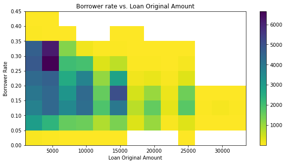

## Monthly Loan Payment vs. Loan Original Amount

Monthly loan payment and the original amount of the loan have a positive relationship which means the higher the loan taken the higher monthly payment made on the loan. This is actually expected, the relationship is seen clearer on a logarithmic scale.

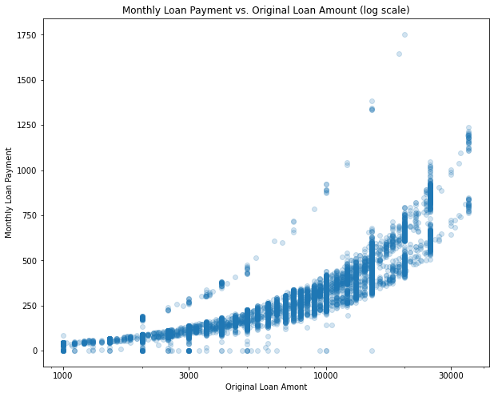

## Distribution of Loan Status, Income Range and Credit Grade against Loan Original Amount

For `loan status`, there are low frequently occuring values for the different category and loan original amount,there is an exception in the cancelled category which has a wider PDF with most of the values occuring between 0 - 5000, this could imply that lower amount of loans taken are more likely to get cancelled.

The plot for `credit grade` shows extremely narrow PDF for ratings AA - B, narrow PDF for C and D then a wider PDF for E - NC. This could mean those with ratings AA - B don't have a limit to the amount of loan that can be granted, ratings C and D have limited opportunity to access high loan amount and E - NC mostly get considered for lower sum of loans.

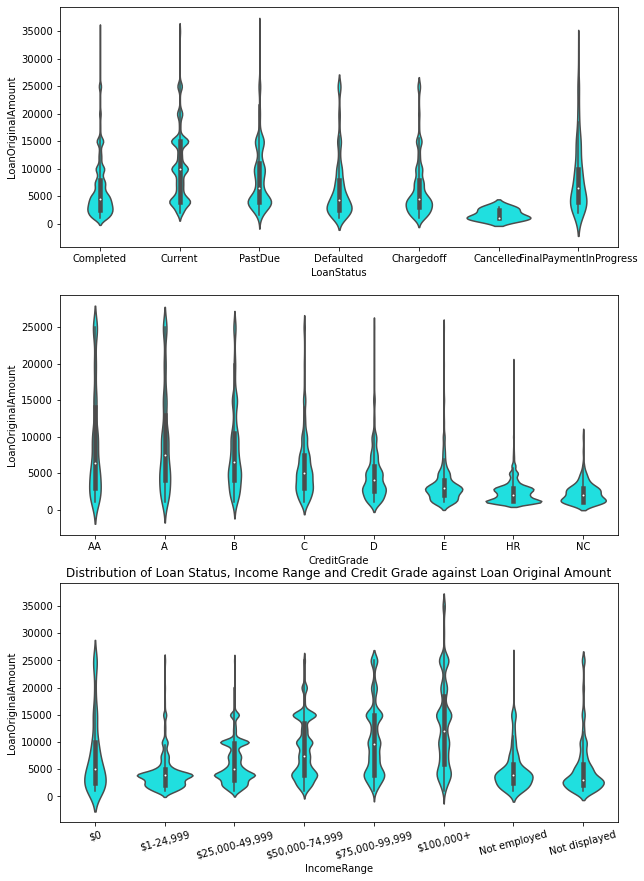

## Relationship between Credit Grade and Loan Status on Loan Original Amount

- Across all ratings there are loans with completed status though the average amount completed gets lower as the ratings reduce.
- The defaulted loan status is seen across all ratings, but there fewer loans in ratings AA-C
- The chargedoff loan status (this means loan written of as bad debt) is predominant across all ratings, ratings AA-B have fewer loans of that status.
- The cancelled loan status is seen in the A, C and HR rating for very low loan amounts, the error bars in rating HR mean there is fewer loan amount of that status.

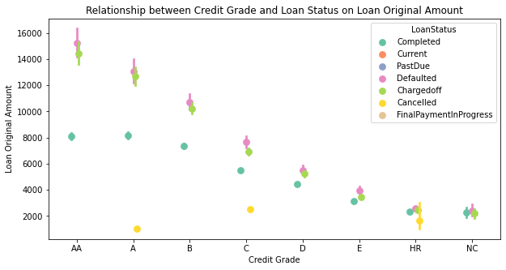